# Google Trends Prediction

2020-06-26 01:49:14

This is a replication of the result of a paper conducted by Choi and Varian to “nowcast” different economic variables from google trends data.

We’re taking the cleaned data used for the paper(2004-1011) and taking the log of the features.

```r
auto <- read_csv("merged.csv")
auto_sales <- auto %>%
  mutate(lag_1 = lag(sales, 1),
         lag_12 = lag(sales,12),log_sales =log(sales))
auto_sales
```

```
## # A tibble: 91 x 7
##    Period     sales  suvs insurance lag_1 lag_12 log_sales
##    <date>     <dbl> <dbl>     <dbl> <dbl>  <dbl>     <dbl>
##  1 2004-01-01 61287  0         0       NA     NA      11.0
##  2 2004-02-01 65381 -0.12     -0.01 61287     NA      11.1
##  3 2004-03-01 78843 -0.05     -0.09 65381     NA      11.3
##  4 2004-04-01 73422 -0.12     -0.08 78843     NA      11.2
##  5 2004-05-01 77662 -0.07     -0.07 73422     NA      11.3
##  6 2004-06-01 75516 -0.12      0.01 77662     NA      11.2
##  7 2004-07-01 78991 -0.14      0.07 75516     NA      11.3
##  8 2004-08-01 76521 -0.09      0.05 78991     NA      11.2
##  9 2004-09-01 73711 -0.12     -0.07 76521     NA      11.2
## 10 2004-10-01 68880 -0.14     -0.06 73711     NA      11.1
## # ... with 81 more rows
```

According to the paper the model they used for nowcasting is an AR-1 model yt = b1yt−1 + b12yt−12 + et for the period 2004-01-01 to 2011-07-01 where yt is the log of the observation at time t.

So we applied the same model for both the base and trends data. We get the same table as they have on the paper including the R^2 and coefficients.

```r
model_base <- lm(log_sales ~ log(lag_1) + log(lag_12), data = auto_sales)
summary(model_base)
```

```
##
## Call:
## lm(formula = log_sales ~ log(lag_1) + log(lag_12), data = auto_sales)
##
## Residuals:
##       Min        1Q    Median        3Q       Max
## -0.209554 -0.034684  0.002482  0.040477  0.220976
##
## Coefficients:
##             Estimate Std. Error t value Pr(>|t|)
## (Intercept)  0.67266    0.76355   0.881 0.381117
## log(lag_1)   0.64345    0.07332   8.776 3.59e-13 ***
## log(lag_12)  0.29565    0.07282   4.060 0.000118 ***
## ---
## Signif. codes:  0 '***' 0.001 '**' 0.01 '*' 0.05 '.' 0.1 ' ' 1
##
## Residual standard error: 0.07985 on 76 degrees of freedom
##   (12 observations deleted due to missingness)
## Multiple R-squared:  0.7185, Adjusted R-squared:  0.7111
## F-statistic:    97 on 2 and 76 DF,  p-value: < 2.2e-16
```

```r
model_trends <- lm(log_sales ~ log(lag_1) + log(lag_12) + suvs + insurance, data = auto_sales)
summary(model_trends)
```

```
##
## Call:
## lm(formula = log_sales ~ log(lag_1) + log(lag_12) + suvs + insurance,
##     data = auto_sales)
##
## Residuals:
##       Min        1Q    Median        3Q       Max
## -0.161327 -0.043774  0.002998  0.036651  0.159219
##
## Coefficients:
##             Estimate Std. Error t value Pr(>|t|)
## (Intercept) -0.45798    0.78438  -0.584 0.561081
## log(lag_1)   0.61947    0.06318   9.805 5.09e-15 ***
## log(lag_12)  0.42865    0.06535   6.559 6.45e-09 ***
## suvs         1.05721    0.16686   6.336 1.66e-08 ***
## insurance   -0.52966    0.15206  -3.483 0.000835 ***
## ---
## Signif. codes:  0 '***' 0.001 '**' 0.01 '*' 0.05 '.' 0.1 ' ' 1
##
## Residual standard error: 0.06509 on 74 degrees of freedom
##   (12 observations deleted due to missingness)
## Multiple R-squared:  0.8179, Adjusted R-squared:  0.808
## F-statistic: 83.08 on 4 and 74 DF,  p-value: < 2.2e-16
```

Now we use a rolling window forecast approach like the one they did on the paper to use the data from K(which they chose to be 17) upto t-1 to estimate the model.

```r
rolling_base <- lm(log_sales ~ log(lag_1) +
                   log(lag_12), data = auto_sales[1:17,])

rolling_trends <- lm(log_sales ~ log(lag_1) + log(lag_12) +
                  suvs + insurance, data = auto_sales[1:17,])

rolling_all <- auto_sales %>% mutate(base = 0, trends= 0, actual =
                log_sales)

rolling_all
```

```
## # A tibble: 91 x 10
##    Period     sales  suvs insurance lag_1 lag_12 log_sales  base trends actual
##    <date>     <dbl> <dbl>     <dbl> <dbl>  <dbl>     <dbl> <dbl>  <dbl>  <dbl>
##  1 2004-01-01 61287  0         0       NA     NA      11.0     0      0   11.0
##  2 2004-02-01 65381 -0.12     -0.01 61287     NA      11.1     0      0   11.1
##  3 2004-03-01 78843 -0.05     -0.09 65381     NA      11.3     0      0   11.3
##  4 2004-04-01 73422 -0.12     -0.08 78843     NA      11.2     0      0   11.2
##  5 2004-05-01 77662 -0.07     -0.07 73422     NA      11.3     0      0   11.3
##  6 2004-06-01 75516 -0.12      0.01 77662     NA      11.2     0      0   11.2
##  7 2004-07-01 78991 -0.14      0.07 75516     NA      11.3     0      0   11.3
##  8 2004-08-01 76521 -0.09      0.05 78991     NA      11.2     0      0   11.2
##  9 2004-09-01 73711 -0.12     -0.07 76521     NA      11.2     0      0   11.2
## 10 2004-10-01 68880 -0.14     -0.06 73711     NA      11.1     0      0   11.1
## # ... with 81 more rows
```

```r
K <- 18:91

for (k in K){

  rolling_base <- lm(actual ~ log(lag_1) + log(lag_12), data =       rolling_all[1:k-1,])

   rolling_trends <- lm(actual ~ log(lag_1) + log(lag_12) + suvs + insurance, data = rolling_all[1:k-1,])


   rolling_all$base[k] <- predict(rolling_base, rolling_all[k,])

   rolling_all$trends[k] <- predict(rolling_trends, rolling_all[k,])

}
rolling_all
```

```
## # A tibble: 91 x 10
##    Period     sales  suvs insurance lag_1 lag_12 log_sales  base trends actual
##    <date>     <dbl> <dbl>     <dbl> <dbl>  <dbl>     <dbl> <dbl>  <dbl>  <dbl>
##  1 2004-01-01 61287  0         0       NA     NA      11.0     0      0   11.0
##  2 2004-02-01 65381 -0.12     -0.01 61287     NA      11.1     0      0   11.1
##  3 2004-03-01 78843 -0.05     -0.09 65381     NA      11.3     0      0   11.3
##  4 2004-04-01 73422 -0.12     -0.08 78843     NA      11.2     0      0   11.2
##  5 2004-05-01 77662 -0.07     -0.07 73422     NA      11.3     0      0   11.3
##  6 2004-06-01 75516 -0.12      0.01 77662     NA      11.2     0      0   11.2
##  7 2004-07-01 78991 -0.14      0.07 75516     NA      11.3     0      0   11.3
##  8 2004-08-01 76521 -0.09      0.05 78991     NA      11.2     0      0   11.2
##  9 2004-09-01 73711 -0.12     -0.07 76521     NA      11.2     0      0   11.2
## 10 2004-10-01 68880 -0.14     -0.06 73711     NA      11.1     0      0   11.1
## # ... with 81 more rows
```

Now we can plot our actual plus base and trends predictions to see if they have any disparities and to compare them.

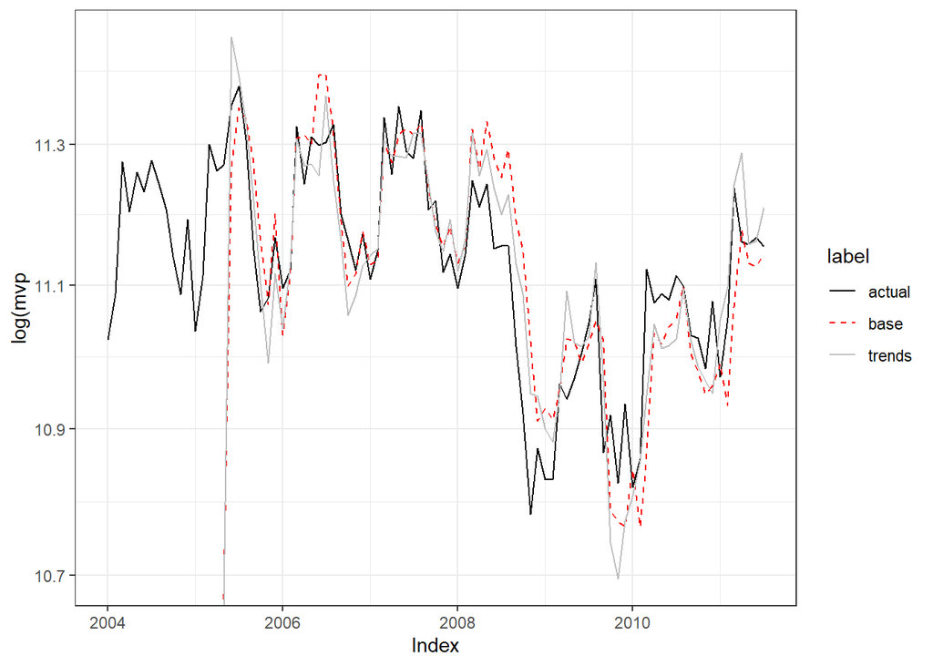

```r
rolling_all %>% pivot_longer(names_to = "label", values_to = "value", c("actual","base","trends")) %>%
ggplot(aes(x=Period, y = value,color = label, linetype = label))+
geom_line(aes(y = value, color = label, linetype= label))+
scale_colour_manual(values=c("black", "red","grey"))+ scale_y_log10() +
scale_linetype_manual(values = c("solid", "dashed", "solid"))+
xlab('Index')+ ylab('log(mvp')
```

We also get a plot that’s very close to the original plot on the paper.

```r
mae_base <- mean(abs(rolling_all$log_sales - rolling_all$base))

mae_trends <- mean(abs(rolling_all$log_sales - rolling_all$trends))
```

Trying out the model with raw data. Getting the data from 01/2004 - 07/2011, reading the data and joining sales, insurance and trucks & suvs data frame together.

```r
sales <- read_xls("sales.xls")
year_month <- as.yearmon(sales$Period, "%b-%Y")
sales$Period <- as.Date(year_month)

insurance <- read_csv("New_auto_insurance.csv")
insurance <- insurance %>% rename(Period = Month, insurance = `Geo: United States`)

suvs <- read_csv("New_Trucks_suvs.csv")
suvs <- suvs %>% rename(Period = Month, suvs = `Geo: United States`)

insurance_suvs <- left_join(insurance, suvs, by = "Period") %>%
  mutate(Period = as.Date(as.yearmon(Period, "%Y-%m")))

join_all <- left_join(insurance_suvs, sales, by = "Period") %>% mutate(sales = as.numeric(Value))
join_all
```

```
## # A tibble: 91 x 5
##    Period     insurance  suvs Value sales
##    <date>         <dbl> <dbl> <chr> <dbl>
##  1 2004-01-01        93    97 61146 61146
##  2 2004-02-01        90    97 65230 65230
##  3 2004-03-01        87    93 78662 78662
##  4 2004-04-01        91    94 73252 73252
##  5 2004-05-01        86    92 77491 77491
##  6 2004-06-01        97    93 75355 75355
##  7 2004-07-01        97    97 78837 78837
##  8 2004-08-01       100    98 76377 76377
##  9 2004-09-01        90   100 73580 73580
## 10 2004-10-01        82    87 68745 68745
## # ... with 81 more rows
```

Adding the baseline model to the combined data

```r
join_all <- join_all %>% mutate(mont_1 = lag(sales, 1), mont_12 = lag(sales,12), sales =log(sales))

model_1 <- lm(sales ~ mont_1 + mont_12, data = join_all)
summary(model_1)
```

```
##
## Call:
## lm(formula = sales ~ mont_1 + mont_12, data = join_all)
##
## Residuals:
##      Min       1Q   Median       3Q      Max
## -0.20714 -0.04777  0.00366  0.05085  0.21202
##
## Coefficients:
##              Estimate Std. Error t value Pr(>|t|)
## (Intercept) 1.015e+01  7.176e-02 141.488  < 2e-16 ***
## mont_1      9.657e-06  1.124e-06   8.591  8.1e-13 ***
## mont_12     4.434e-06  1.116e-06   3.972 0.000161 ***
## ---
## Signif. codes:  0 '***' 0.001 '**' 0.01 '*' 0.05 '.' 0.1 ' ' 1
##
## Residual standard error: 0.08107 on 76 degrees of freedom
##   (12 observations deleted due to missingness)
## Multiple R-squared:  0.7147, Adjusted R-squared:  0.7072
## F-statistic: 95.21 on 2 and 76 DF,  p-value: < 2.2e-16
```

```r
model_2 <- lm(sales ~ mont_1 + mont_12 + insurance + suvs, data = join_all)
summary(model_2)
```

```
##
## Call:
## lm(formula = sales ~ mont_1 + mont_12 + insurance + suvs, data = join_all)
##
## Residuals:
##       Min        1Q    Median        3Q       Max
## -0.188557 -0.042807  0.005374  0.039773  0.219111
##
## Coefficients:
##               Estimate Std. Error t value Pr(>|t|)
## (Intercept)  9.873e+00  1.027e-01  96.095  < 2e-16 ***
## mont_1       8.252e-06  1.232e-06   6.699 3.56e-09 ***
## mont_12      4.797e-06  1.091e-06   4.398 3.60e-05 ***
## insurance   -6.325e-03  2.025e-03  -3.123  0.00255 **
## suvs         1.071e-02  2.536e-03   4.221 6.82e-05 ***
## ---
## Signif. codes:  0 '***' 0.001 '**' 0.01 '*' 0.05 '.' 0.1 ' ' 1
##
## Residual standard error: 0.07244 on 74 degrees of freedom
##   (12 observations deleted due to missingness)
## Multiple R-squared:  0.7782, Adjusted R-squared:  0.7662
## F-statistic: 64.92 on 4 and 74 DF,  p-value: < 2.2e-16
```

Now we’re gonna use the rolling window forecasting model.

```r
new_join <- join_all %>% mutate(base = 0, trends = 0, actual = sales)

new_join
```

```
## # A tibble: 91 x 10
##    Period     insurance  suvs Value sales mont_1 mont_12  base trends actual
##    <date>         <dbl> <dbl> <chr> <dbl>  <dbl>   <dbl> <dbl>  <dbl>  <dbl>
##  1 2004-01-01        93    97 61146  11.0     NA      NA     0      0   11.0
##  2 2004-02-01        90    97 65230  11.1  61146      NA     0      0   11.1
##  3 2004-03-01        87    93 78662  11.3  65230      NA     0      0   11.3
##  4 2004-04-01        91    94 73252  11.2  78662      NA     0      0   11.2
##  5 2004-05-01        86    92 77491  11.3  73252      NA     0      0   11.3
##  6 2004-06-01        97    93 75355  11.2  77491      NA     0      0   11.2
##  7 2004-07-01        97    97 78837  11.3  75355      NA     0      0   11.3
##  8 2004-08-01       100    98 76377  11.2  78837      NA     0      0   11.2
##  9 2004-09-01        90   100 73580  11.2  76377      NA     0      0   11.2
## 10 2004-10-01        82    87 68745  11.1  73580      NA     0      0   11.1
## # ... with 81 more rows
```

```r
K <- 18:91

for (k in K){

  rolling_base <- lm(actual ~ mont_1 + mont_12, data = new_join[1:k-1,])

   rolling_trends <- lm(actual ~ mont_1 + mont_12 + suvs + insurance, data = new_join[1:k-1,])


   new_join$base[k] <- predict(rolling_base, new_join[k,])

   new_join$trends[k] <- predict(rolling_trends, new_join[k,])

}
new_join
```

```
## # A tibble: 91 x 10
##    Period     insurance  suvs Value sales mont_1 mont_12  base trends actual
##    <date>         <dbl> <dbl> <chr> <dbl>  <dbl>   <dbl> <dbl>  <dbl>  <dbl>
##  1 2004-01-01        93    97 61146  11.0     NA      NA     0      0   11.0
##  2 2004-02-01        90    97 65230  11.1  61146      NA     0      0   11.1
##  3 2004-03-01        87    93 78662  11.3  65230      NA     0      0   11.3
##  4 2004-04-01        91    94 73252  11.2  78662      NA     0      0   11.2
##  5 2004-05-01        86    92 77491  11.3  73252      NA     0      0   11.3
##  6 2004-06-01        97    93 75355  11.2  77491      NA     0      0   11.2
##  7 2004-07-01        97    97 78837  11.3  75355      NA     0      0   11.3
##  8 2004-08-01       100    98 76377  11.2  78837      NA     0      0   11.2
##  9 2004-09-01        90   100 73580  11.2  76377      NA     0      0   11.2
## 10 2004-10-01        82    87 68745  11.1  73580      NA     0      0   11.1
## # ... with 81 more rows
```

Again, let’s plot all of these together to get a sense of how they compare with another and also to compare the plot with the earlier plot that we did with the clean data.

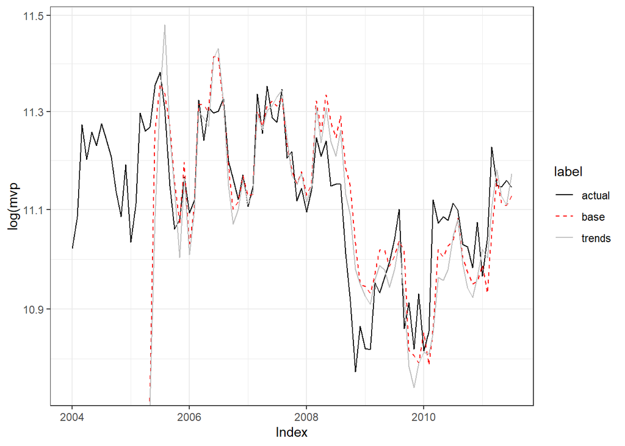

```r
new_join %>% pivot_longer(names_to = "label", values_to = "value", c("actual","base","trends")) %>%
ggplot(aes(x=Period, y = value,color = label, linetype = label))+
geom_line(aes(y = value, color = label, linetype= label))+
scale_colour_manual(values=c("black", "red","grey"))+ scale_y_log10() +
scale_linetype_manual(values = c("solid", "dashed", "solid"))+
xlab('Index')+ ylab('log(mvp')
```

Also a very similar plot to the other one.